# ML HOSPITAL READMISSION CASE STUDY

## ML Case Study - Hospital Readmission Prediction

### Objective:

Investigate and identify key factors contributing to hospital readmissions, which occur when patients are readmitted to the hospital shortly after discharge. By analyzing these factors, the goal is to develop predictive models that can assist in anticipating which patients are more likely to experience readmission.

### Import Libraries

```python
import pandas as pd
import numpy as np
import seaborn as sns

import matplotlib.pyplot as plt
from sklearn.metrics import classification_report

#BLR
from sklearn.model_selection import train_test_split
from sklearn.linear_model import LogisticRegression


#NB
from sklearn.naive_bayes import GaussianNB
from sklearn.metrics import roc_curve, roc_auc_score

#svm
from sklearn.svm import SVC

import warnings
warnings.filterwarnings("ignore", category=FutureWarning)
```

### Import Data

```python
data = pd.read_csv('Hospital Readmissions.csv')
data.head()
```

|  | id | age | time_in_hospital | n_lab_procedures | n_procedures | n_medications | n_outpatient | n_inpatient | n_emergency | diagnosis | glucose_test | A1Ctest | change | diabetes_med | readmitted |
| --- | --- | --- | --- | --- | --- | --- | --- | --- | --- | --- | --- | --- | --- | --- | --- |
| 0 | 1 | [70-80) | 8 | 72 | 1 | 18 | 2 | 0 | 0 | Circulatory | no | no | no | yes | no |
| 1 | 2 | [70-80) | 3 | 34 | 2 | 13 | 0 | 0 | 0 | Other | no | no | no | yes | no |
| 2 | 3 | [50-60) | 5 | 45 | 0 | 18 | 0 | 0 | 0 | Circulatory | no | no | yes | yes | yes |
| 3 | 4 | [70-80) | 2 | 36 | 0 | 12 | 1 | 0 | 0 | Circulatory | no | no | yes | yes | yes |
| 4 | 5 | [60-70) | 1 | 42 | 0 | 7 | 0 | 0 | 0 | Other | no | no | no | yes | no |

### Data Description

| Field | Description |
| --- | --- |
| age | Age bracket of the patient |
| time_in_hospital | Days (from 1 to 14) |
| n_procedures | Number of procedures performed during the hospital stay |
| n_lab_procedures | Number of laboratory procedures during the hospital stay |
| n_medications | Number of medications administered during the hospital stay |
| n_outpatient | Number of outpatient visits in the year before a hospital stay |
| n_inpatient | Number of inpatient visits in the year before the hospital stay |
| n_emergency | Number of visits to the emergency room in the year before the hospital stay |
| diagnosis | Primary diagnosis (Circulatory, Respiratory, Digestive, etc.) |
| glucose_test | Whether the glucose serum came out as high (> 200), normal, or not performed |
| A1Ctest | Whether the A1C level of the patient came out as high (> 7%), normal, or not performed |
| change | Whether there was a change in the diabetes medication ('yes' or 'no') |
| diabetes_med | Whether a diabetes medication was prescribed ('yes' or 'no') |
| readmitted | If the patient was readmitted at the hospital ('yes' or 'no') |

#### Converting data types (Required for modelling)

```python
data['readmitted'] = data['readmitted'].astype('category')
data['readmitted'] = data['readmitted'].cat.codes
```

##### Note:

The cat.codes operation, when applied to a categorical column, assigns unique integer codes to each category. No is coded as 0 and Yes is coded as 1

```python
data_types_dict = {
    'age': 'category',
    'diagnosis': 'category',
    'glucose_test': 'category',
    'A1Ctest': 'category',
    'change': 'category',
    'diabetes_med': 'category'
}

# Convert data types using the dictionary
data = data.astype(data_types_dict)
```

### Hospital Readmission Status Overview: Visualisation

##### 1. Pie Chart showing % readmission

```
readmitted
0    0.52984
1    0.47016
Name: proportion, dtype: float64
```

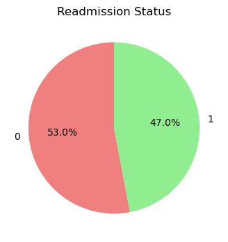

```python
# Count the occurrences of each value in the 'readmitted' column
df=data.copy()
readmitted_counts = df['readmitted'].value_counts(normalize=True)
print(readmitted_counts)
# Create a pie chart
plt.figure(figsize=(4,4))
plt.pie(readmitted_counts, labels=readmitted_counts.index, autopct='%1.1f%%', startangle=90, colors=['lightcoral', 'lightgreen'])
plt.title('Readmission Status')
plt.show()
```

##### 2. Boxplot for Number of lab procedures during the hospital stay, Stratified by Readmission Status

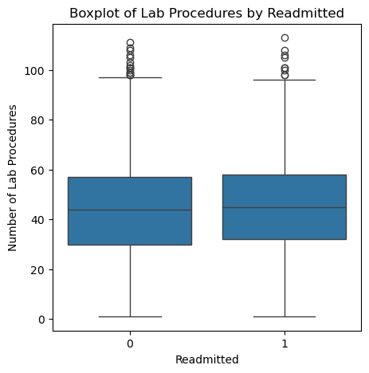

```python
# Create boxplot for n_outpatient by readmitted
df=data.copy()
plt.figure(figsize=(5, 5))
sns.boxplot(x='readmitted', y='n_lab_procedures', data=df)
plt.title('Boxplot of Lab Procedures by Readmitted')
plt.xlabel('Readmitted')
plt.ylabel('Number of Lab Procedures')
plt.show()
```

##### 3. Bar Graph Illustrating the Percentage of Readmitted Cases Across Different Age Groups

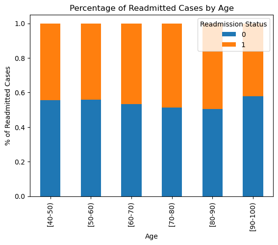

```python
# Group by 'age' and 'readmitted', calculate the normalized value counts
grouped_data = df.groupby('age')['readmitted'].value_counts(normalize=True).unstack()

# Create a bar plot
plt.figure(figsize=(12, 6))
grouped_data.plot(kind='bar', stacked=True)
plt.title('Percentage of Readmitted Cases by Age')
plt.xlabel('Age')
plt.ylabel('% of Readmitted Cases')
plt.legend(title='Readmission Status', loc='upper right')
plt.show()
```

##### 4. Bar Graph Illustrating the Percentage of Readmitted Cases Across Different Diagnosis

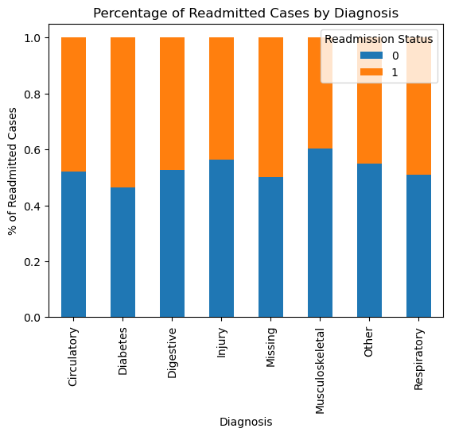

```python
# Create a bar graph for Diagnosis and % of readmitted
grouped_data = df.groupby('diagnosis')['readmitted'].value_counts(normalize=True).unstack()

# Create a bar plot
plt.figure(figsize=(12, 6))
grouped_data.plot(kind='bar', stacked=True)
plt.title('Percentage of Readmitted Cases by Diagnosis')
plt.xlabel('Diagnosis')
plt.ylabel('% of Readmitted Cases')
plt.legend(title='Readmission Status', loc='upper right')
plt.show()
```

### Model 1. Binary Logistic Regression

Splitting Data into Train and Test data sets

```python
x_variables =['age', 'time_in_hospital', 'n_lab_procedures', 'n_procedures',
       'n_medications', 'n_outpatient', 'n_inpatient', 'n_emergency',
       'diagnosis', 'glucose_test', 'A1Ctest', 'change', 'diabetes_med']

X = data.loc[:,x_variables]
y = data.loc[:, 'readmitted']

#Creating dummies for categorical variables (required for ML algorithms)
X = pd.get_dummies(X, columns=['age','diagnosis', 'glucose_test', 'A1Ctest', 'change', 'diabetes_med'], drop_first=True)

#Splitting data into train and test
X_train, X_test, y_train, y_test = train_test_split(X, y,
                                                   test_size=0.30,
                                                   random_state = 0)
```

```python
threshold = 0.45 #One can try out different thresholds
```

### Note:

Threshold can be adjusted to balance the sensitivity and specificity.

Building Model

```python
# Initialize the logistic regression model
logreg =LogisticRegression(max_iter=1000)

# Fit the model on the training data
logreg.fit(X_train, y_train)
```

```
LogisticRegression(max_iter=1000)
```

### Note :

The logit() in statsmodels library provides table of coefficients, standard error and p values for hypothesis testing. However, the LogisticRegression() in sklearn follows ML approach with focus on predictions.

Predicting probabilities

```python
# Predict the class labels
y_pred = logreg.predict(X_test)
```

```python
predprob_test = logreg.predict_proba(X_test)
pred_test = np.where(predprob_test[:,1] > threshold, 1, 0)
```

Generate Classification Report

```python
print(classification_report(y_test,pred_test))
```

```
              precision    recall  f1-score   support

           0       0.61      0.67      0.64      3880
           1       0.60      0.53      0.57      3620

    accuracy                           0.60      7500
   macro avg       0.60      0.60      0.60      7500
weighted avg       0.60      0.60      0.60      7500
```

Computing AUC value for ROC curve

```python
auc = roc_auc_score(y_test,predprob_test[:,1])
print('AUC: %.3f' % auc)
```

```
AUC: 0.642
```

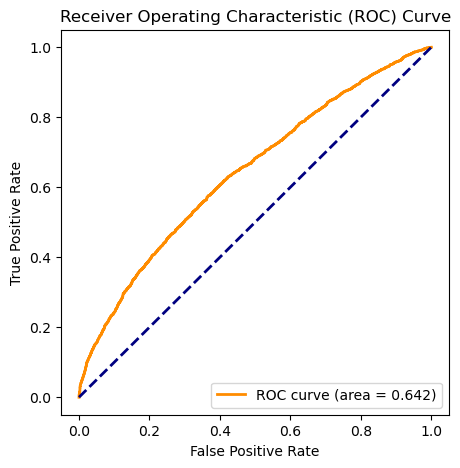

```python
# Plot ROC Curve for Test data
fpr, tpr, _ = roc_curve(y_test, predprob_test[:,1])
plt.figure(figsize=(5, 5))
lw=2
plt.plot(fpr, tpr, color='darkorange',lw=lw, label='ROC curve (area = %0.3f)' % auc)
plt.plot([0, 1], [0, 1], color='navy', lw=lw, linestyle='--')
plt.title('Receiver Operating Characteristic (ROC) Curve')
plt.xlabel('False Positive Rate')
plt.ylabel('True Positive Rate')
plt.legend(loc='lower right')
plt.show()
```

## Observation :

The overall model accuracy is 60%. The area under ROC curve is 0.64

### Model 2. Naive Bayes

The scikit-learn library has two functions for Naive Bayes method:

1. GaussianNB() for numeric predictors
2. MultinomialNB() for categorical predictors

Here, we use GaussianNB() by converting categorical variables into numeric variables(dummy variables). This is a general industry practice. However one can convert numeric variable into categorical variable using MultinomialNB()

For example :

Convert 'time_in_hospital' to quartile categories

data['time_in_hospital'] = pd.qcut(data['time_in_hospital'], q=4, labels=['Q1', 'Q2', 'Q3', 'Q4'])

Building Model

```python
# Create and fit the Gaussian Naive Bayes model
NBmodel = GaussianNB()

NBmodel.fit(X_train, y_train)
```

```
GaussianNB()
```

Predicting probabilities

```python
# Make predictions on the test set
y_pred = NBmodel.predict(X_test)
```

```python
predprob_test = NBmodel.predict_proba(X_test)
pred_test = np.where(predprob_test[:,1] > threshold, 1, 0)
```

Generating Classification Report

```python
print(classification_report(y_test,pred_test))
```

```
              precision    recall  f1-score   support

           0       0.57      0.81      0.67      3880
           1       0.63      0.33      0.44      3620

    accuracy                           0.58      7500
   macro avg       0.60      0.57      0.55      7500
weighted avg       0.60      0.58      0.56      7500
```

```python
auc = roc_auc_score(y_test, predprob_test[:,1])
print('AUC: %.3f' % auc)
```

```
AUC: 0.622
```

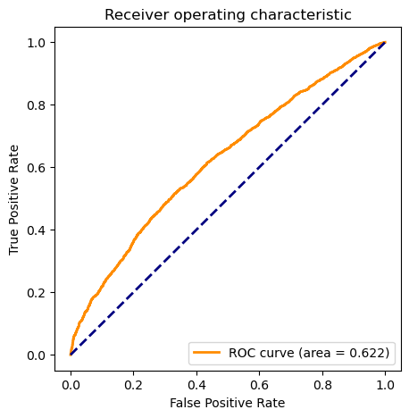

```python
NBfpr, NBtpr, thresholds = roc_curve(y_test, predprob_test[:,1])

# plot the roc curve for Test data
plt.figure(figsize=(5, 5))
lw = 2
plt.plot(NBfpr, NBtpr, color='darkorange',lw=lw, label='ROC curve (area = %0.3f)' % auc)
plt.plot([0, 1], [0, 1], color='navy', lw=lw, linestyle='--')
plt.axis('tight')
plt.xlabel('False Positive Rate');plt.ylabel('True Positive Rate')
plt.title('Receiver operating characteristic')
plt.legend(loc="lower right")
plt.show()
```

##### Observation :

The overall model accuracy is 58%. The area under ROC curve is 0.62

### Model 3. Support Vector Machine (SVM)

Building Model

```python
svm_model = SVC(probability=True, random_state=0)
```

##### Note:

The 'rbf' kernel is used. If you want to explicitly specify a linear kernel, you can do so by setting the kernel parameter.

```python
svm_model.fit(X_train, y_train)
```

```
SVC(probability=True, random_state=0)
```

Predicting probabilities

```python
y_prob = svm_model.predict_proba(X_test)[:, 1]
```

Generate Classification Report

```python
y_pred = svm_model.predict(X_test)
classification_rep = classification_report(y_test, y_pred)
print("Classification Report:")
print(classification_rep)
```

```
Classification Report:
              precision    recall  f1-score   support

           0       0.56      0.91      0.69      3880
           1       0.70      0.23      0.35      3620

    accuracy                           0.58      7500
   macro avg       0.63      0.57      0.52      7500
weighted avg       0.63      0.58      0.53      7500
```

Computing AUC value for ROC curve

```python
# Calculate AUC
roc_auc = roc_auc_score(y_test, y_prob)
print(f"AUC: {roc_auc:.5f}")
```

```
AUC: 0.64500
```

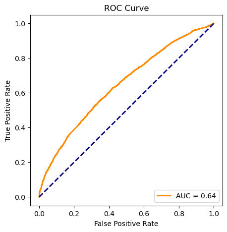

```python
# Plot ROC curve for test data
fpr, tpr, thresholds = roc_curve(y_test, y_prob)
plt.figure(figsize=(5,5))
plt.plot(fpr, tpr, color='darkorange', lw=2, label=f'AUC = {roc_auc:.2f}')
plt.plot([0, 1], [0, 1], color='navy', lw=2, linestyle='--')
plt.xlabel('False Positive Rate')
plt.ylabel('True Positive Rate')
plt.title('ROC Curve')
plt.legend(loc='lower right')
plt.show()
```

##### Observations :

The overall model accuracy is 58%. The area under ROC curve is 64

#### Conclusion:

The SVM method gives highest AUC for test data ( 0.64) when compared with Logistic Regression and Naive Bayes method.